# Тенденции выбора падежной формы в конструкциях типа Фермер продал три овцы // трех овец.

Ангелина Присяжная

## Введение

Вариативность (наличие нескольких вариантов чего-либо) – очень распространенное явление в русском языке. Она имеет место в различных областях языка, в том числе и в морфологии. Интересно изучить то, что именно влияет на выбор того или иного варианта из нескольких возможных, а также выявить тенденции этого выбора.

Для более подробного изучения взяты конструкции типа Фермер продал три овцы // трех овец. Целью данной работы является выявление тенденций выбора падежной формы в этих конструкциях и определение факторов, влияющих на этот выбор.

Для изучения были взяты числительные оба, два, три, четыре. Подбор материала осуществлялся с помощью НКРЯ и корпуса SketchEngine. Я использовала лексико-грамматический поиск и вводили следующий запрос: оба/два/три/четыре (в именительном или винительном падеже) + существительное (женского рода, во множественном числе, одушевленное, семантический класс - животное), расстояние между словоформами от 1 до 3. При таком запросе также находятся и диминутивы существительных.

В данных конструкциях может быть использована одушевленная или неодушевленная форма винительного падежа. Формы обе/две/три/четыре будем называть “неодушевленными”, а формы обеих/двух/трех/четырех – “одушевленными”:

*Завтракал Орлов (деж.). Долго гулял, убил **три вороны**. Занимался и писал, а после обеда читал Аликс вслух.* [Николай II. Дневники 1904-1907 (1904-1907)]

*Гейден. Погулял еще и убил **трех ворон**. Занимался с успехом.* [Николай II. Дневники 1904-1907 (1904-1907)]

Из найденных примеров не рассматривались те, в которых использовались существительные пиявка, креветка (для данных существительных в Грамматическом словаре русского языка А.А.Зализняка указаны колебания по одушевленности):

*А теперь припустил себе к носу **две пиявки** да воображает, что у него усы!* [М. Н. Загоскин. Москва и москвичи (1842-1850)]

*Сергей выбрал еще **три креветки**, стараясь найти среди них самые крепкие и привлекательные, наживил каждую из них, тщательно продев крючок сквозь всетуловище, и осторожно опустил за борт свою снасть.* [Фазиль Искандер. Морской скорпион (1977)]

Необходимые библиотеки.

```r
library('languageR')
library('Hmisc')
library(party)
library(lattice)
library(rms)
library(ggplot2)
```

Файлы с данными.

```r
nk = read.csv('/Users/angelinaprisyazhnaya/Desktop/ovtsy_ruscorpora.csv', sep=';')
se = read.csv('/Users/angelinaprisyazhnaya/Desktop/ovtsy_sketch.csv', sep=';')
ovtsy_all = read.csv('/Users/angelinaprisyazhnaya/Desktop/ovtsy_all.csv', sep=';')
```

## Данные из НКРЯ

В НКРЯ было найдено 729 подходящих примеров. На графике показано количество вхождений для различных форм и числительных.

```r
summary(nk)
```

```
##     numeral        form          year       century     homogenious_parts
##  chetyre: 63   anim  :607   Min.   :1709   XIX  :197   no        :575
##  dva    :481   inanim:122   1st Qu.:1892   XVIII: 13   yes_anim  :117
##  oba    : 19                Median :1932   XX   :429   yes_inanim: 37
##  tri    :166                Mean   :1929   XXI  : 90
##                             3rd Qu.:1977
##                             Max.   :2011
##  pair_numerals definiteness adjectives
##  no :711       high  :586   no :577
##  yes: 18       low   : 15   yes:152
##                medium:128
##
##
##
```

```r
head(nk)
```

```
##   numeral   form year century homogenious_parts pair_numerals definiteness
## 1     dva inanim 2011     XXI                no            no         high
## 2     dva inanim 2003     XXI                no           yes          low
## 3     dva inanim 2003     XXI                no            no       medium
## 4     dva inanim 2001     XXI                no            no         high
## 5     dva inanim 2001     XXI          yes_anim            no       medium
## 6     dva inanim 2001     XXI                no           yes          low
##   adjectives
## 1         no
## 2        yes
## 3         no
## 4         no
## 5        yes
## 6         no
```

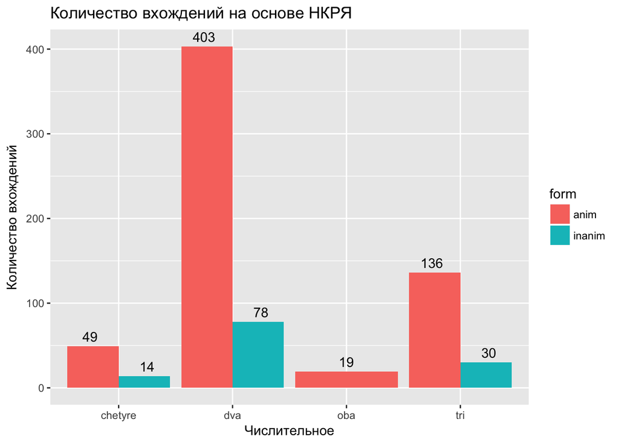

```r
ggplot(nk, aes(numeral)) + geom_bar(aes(fill = form), position="dodge") + geom_text(stat='count',aes(label=..count.., hjust=0.5, vjust=-0.5, group=form), position=position_dodge(width = 1)) + xlab("Числительное") + ylab("Количество вхождений") + ggtitle("Количество вхождений на основе НКРЯ")
```

## Данные из SketchEngine

В SketchEngine было найдено 784 подходящих примера. На графике показано количество вхождений для различных форм и числительных.

```r
summary(se)
```

```
##     numeral        form      homogenious_parts pair_numerals definiteness
##  chetyre: 69   anim  :643   no        :669     no :720       high  :528
##  dva    :508   inanim:141   yes_anim  : 86     yes: 64       low   : 64
##  oba    : 23                yes_inanim: 29                   medium:192
##  tri    :184
##  adjectives
##  no :633
##  yes:151
##
##
```

```r
head(se)
```

```
##   numeral   form homogenious_parts pair_numerals definiteness adjectives
## 1     dva inanim                no            no         high         no
## 2     dva inanim                no            no         high         no
## 3     dva inanim                no            no         high        yes
## 4     dva inanim                no            no         high         no
## 5     dva inanim                no            no         high        yes
## 6     dva inanim                no            no         high         no
```

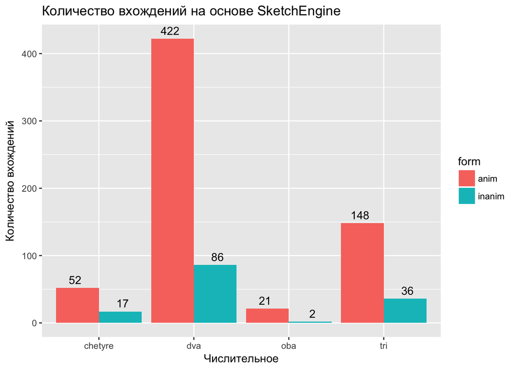

```r
ggplot(se, aes(numeral)) + geom_bar(aes(fill = form), position="dodge") + geom_text(stat='count',aes(label=..count.., hjust=0.5, vjust=-0.5, group=form), position=position_dodge(width = 1)) + xlab("Числительное") + ylab("Количество вхождений") + ggtitle("Количество вхождений на основе SketchEngine")
```

## Факторы

Я предположила, что выбор формы может зависеть от следующих факторов:

- наличие однородных членов;
- двойные числительные;
- определенность;
- наличие определений;
- дата.

### Наличие однородных членов

Возможны три варианта для данного фактора:

- есть одушевленный однородный член (yes_anim)  
  *Сии последние стреляли по двум полкам, оставшимся верными королю, и убили до смерти шестерых всадников и двух лошадей.* [Журнал событиям, совершившимся в Париже в 11-го по 17-е июля 1789 года (1789)]
- есть неодушевленный однородный член (yes_inanim)  
  *Один из грабителей убит, двое скрылись, оставив двух лошадей и ценные вещи.* [неизвестный. Вести (1911.02.13) // «Новое время», 1911]
- нет однородных членов (no)

> Гипотеза: если в предложении содержатся однородные члены в “неодушевленной” форме, то название животного подвергается их влиянию и употребляется в “неодушевленной” форме (и наоборот).

### Двойные числительные

Возможны два варианта для данного фактора:

- двойное числительное (yes)  
  *Лишь некоторые зажиточные вогуличи держали при юртах одну-две коровы.* [Финно-угорские народы. Манси (2001) // «Жизнь национальностей», 2001.12.28]
- обычное одиночное числительное (no)

> Гипотеза: двойные числительные чаще употребляются в “неодушевленной” форме, чем в “одушевленной”.

### Определенность

Возможны три варианта для данного фактора:

- Речь о конкретных объектах, их количество точно определено (high)  
  *Привязав обеих лошадей к прутьям ограды, монах вошел в палисадник.* [Роберт Штильмарк. Наследник из Калькутты (1950-1951)]
- Речь не о конкретных объектах, но их количество точно определено (medium)  
  *На эти деньги мы должны приобрести четырех собак.* [Марта Баранова, Евгений Велтистов. Тяпа, Борька и ракета (1962)]
- Речь не о конкретных объектах, их количество точно не определено (low)  
  *И не зря: как ни пойдешь, всегда тут две-три гадюки увидишь.* [В. В. Бианки. Лесные были и небылицы (1923-1958)]

> Гипотеза: с повышением определенности чаще употребляются “одушевленные” формы.

### Наличие определений

Возможны два варианта для данного фактора:

- есть определение (yes)  
  *Нюра еще издали окинула взглядом путик и поняла, что рыжая лесовая собака не успела пробежаться по нему и напроказить, может, погрызла двух-трех тундровых птиц, никак не больше.* [Владимир Личутин. Вдова Нюра (1973)]
- нет определения (no)

> Гипотеза: при наличии определений чаще употребляются “одушевленные” формы.

### Дата

Возможные варианты для данного фактора: XVIII, XIX, XX, XXI века.

> Цель - проверить, есть ли временная тенденция.

## Дерево решений

Для того, чтобы выяснить, зависит ли выбор падежной формы от каких-либо рассматриваемых факторов, я решила использовать дерево решений.

### Дерево решений на основе данных из НКРЯ

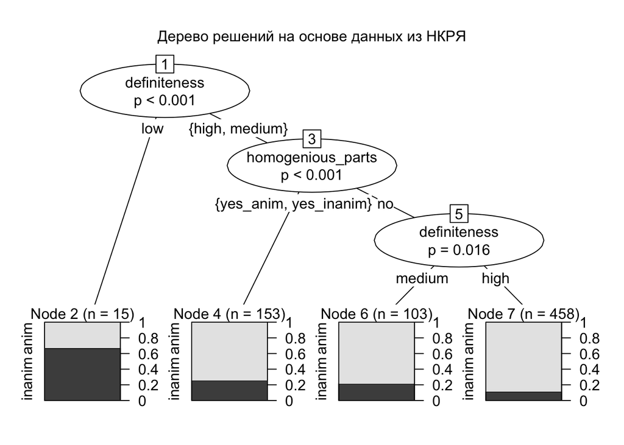

```r
nk.ctree=ctree(form ~ definiteness + homogenious_parts + adjectives, nk)
plot(nk.ctree, main="Дерево решений на основе данных из НКРЯ")
```

### Дерево решений на основе данных из SketchEngine

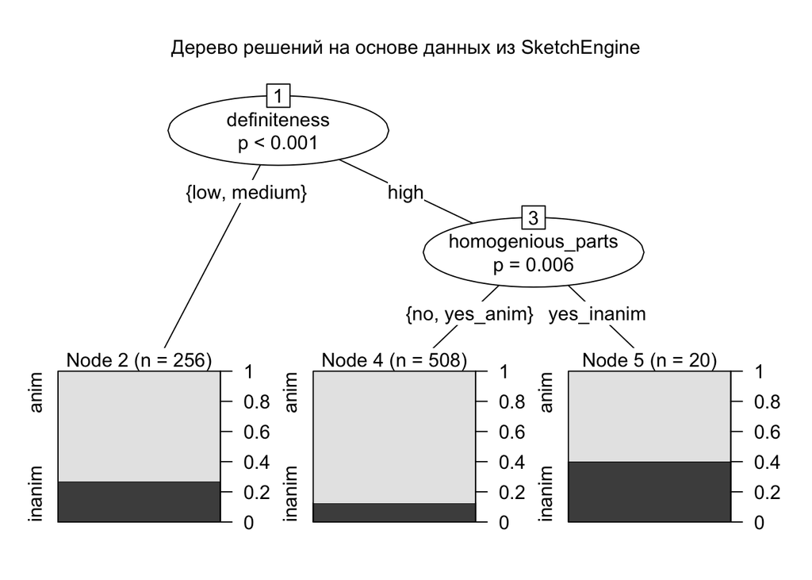

```r
se.ctree=ctree(form ~ definiteness + homogenious_parts + adjectives, se)
plot(se.ctree, main="Дерево решений на основе данных из SketchEngine")
```

Результаты показывают, что на выбор падежной формы действительно влияют следующие факторы:

- определенность (при низкой определенности чаще употребляются “неодушевленные” формы);
- наличие однородных членов (при наличии однородных членов в “неодушевленной” форме чаще употребляются “неодушевленные” формы).

### Дерево решений на основе всех данных

Также я построила дерево для агрегированных данных - и из НКРЯ, и из SketchEngine. Но в этом случае анализ неточный, поскольку некоторые примеры могут встречаться в обеих выборках (дублироваться) - и в НКРЯ, и в SketchEngine. При этом, если это пересечение есть, то оно неравномерно, так как SketchEngine содержит только современные тексты.

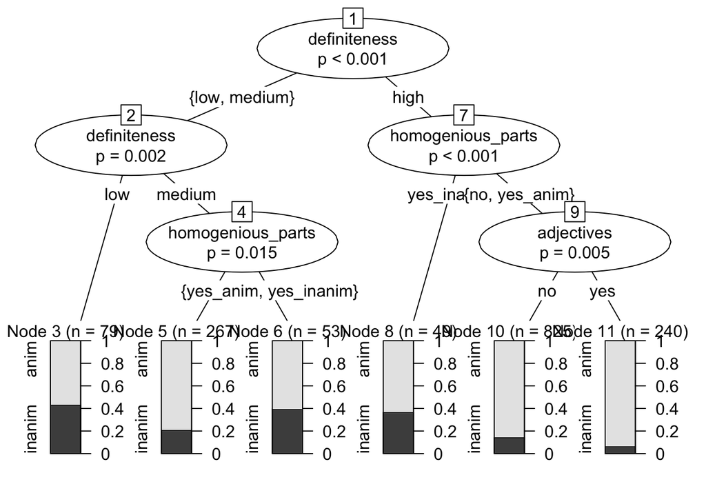

```r
ovtsy_all.ctree=ctree(form ~ definiteness + homogenious_parts + adjectives, ovtsy_all)
plot(ovtsy_all.ctree)
```

### Логистическая регрессия на основе данных из НКРЯ

```r
nk.lrm=lrm(form ~ definiteness + homogenious_parts + adjectives, data=nk, x=T, y=T, linear.predictors=T)
nk.lrm
```

```
## Logistic Regression Model
##
##  lrm(formula = form ~ definiteness + homogenious_parts + adjectives,
##      data = nk, x = T, y = T, linear.predictors = T)
##
##                        Model Likelihood     Discrimination    Rank Discrim.
##                           Ratio Test           Indexes           Indexes
##  Obs           729    LR chi2      49.63    R2       0.111    C       0.675
##   anim         607    d.f.             5    g        0.657    Dxy     0.351
##   inanim       122    Pr(> chi2) <0.0001    gr       1.929    gamma   0.456
##  max |deriv| 8e-09                          gp       0.095    tau-a   0.098
##                                             Brier    0.128
##
##                               Coef    S.E.   Wald Z Pr(>|Z|)
##  Intercept                    -1.9518 0.1511 -12.91 <0.0001
##  definiteness=low              2.7519 0.5721   4.81 <0.0001
##  definiteness=medium           0.7344 0.2424   3.03 0.0025
##  homogenious_parts=yes_anim    0.6643 0.2580   2.57 0.0100
##  homogenious_parts=yes_inanim  1.3023 0.3731   3.49 0.0005
##  adjectives=yes               -0.6693 0.3051  -2.19 0.0283
##
```

Определенность и наличие однородных членов оказывают значимое влияние на выбор падежной формы.

### Логистическая регрессия на основе данных из SketchEngine

```r
se.lrm=lrm(form ~ definiteness + homogenious_parts + adjectives, data=se, x=T, y=T, linear.predictors=T)
se.lrm
```

```
## Logistic Regression Model
##
##  lrm(formula = form ~ definiteness + homogenious_parts + adjectives,
##      data = se, x = T, y = T, linear.predictors = T)
##
##                        Model Likelihood     Discrimination    Rank Discrim.
##                           Ratio Test           Indexes           Indexes
##  Obs           784    LR chi2      41.02    R2       0.084    C       0.651
##   anim         643    d.f.             5    g        0.543    Dxy     0.302
##   inanim       141    Pr(> chi2) <0.0001    gr       1.721    gamma   0.380
##  max |deriv| 1e-09                          gp       0.087    tau-a   0.089
##                                             Brier    0.139
##
##                               Coef    S.E.   Wald Z Pr(>|Z|)
##  Intercept                    -1.9205 0.1490 -12.89 <0.0001
##  definiteness=low              1.3780 0.2921   4.72 <0.0001
##  definiteness=medium           0.6691 0.2165   3.09 0.0020
##  homogenious_parts=yes_anim    0.1673 0.3029   0.55 0.5807
##  homogenious_parts=yes_inanim  1.6137 0.3962   4.07 <0.0001
##  adjectives=yes               -0.2155 0.2655  -0.81 0.4169
##
```

### Логистическая регрессия на основе всех данных

Регрессию я также применила и к агрегированным данным (но здесь та же проблема - данные могут дублироваться).

```r
ovtsy_all.lrm=lrm(form ~ definiteness + homogenious_parts + adjectives, data=ovtsy_all, x=T, y=T, linear.predictors=T)
ovtsy_all.lrm
```

```
## Logistic Regression Model
##
##  lrm(formula = form ~ definiteness + homogenious_parts + adjectives,
##      data = ovtsy_all, x = T, y = T, linear.predictors = T)
##
##                        Model Likelihood     Discrimination    Rank Discrim.
##                           Ratio Test           Indexes           Indexes
##  Obs          1513    LR chi2      82.58    R2       0.088    C       0.659
##   anim        1250    d.f.             5    g        0.585    Dxy     0.319
##   inanim       263    Pr(> chi2) <0.0001    gr       1.795    gamma   0.405
##  max |deriv| 8e-09                          gp       0.090    tau-a   0.092
##                                             Brier    0.135
##
##                               Coef    S.E.   Wald Z Pr(>|Z|)
##  Intercept                    -1.9298 0.1056 -18.27 <0.0001
##  definiteness=low              1.6473 0.2475   6.66 <0.0001
##  definiteness=medium           0.6915 0.1603   4.31 <0.0001
##  homogenious_parts=yes_anim    0.4403 0.1940   2.27 0.0233
##  homogenious_parts=yes_inanim  1.4107 0.2685   5.25 <0.0001
##  adjectives=yes               -0.4187 0.1986  -2.11 0.0350
##
```

## Временная тенденция

Отдельно от всех рассмотренных факторов рассмотрим дату, чтобы выяснить, существует ли какая-либо зависимость употребления падежной формы от времени. В данном случае будут рассматриваться только данные НКРЯ, так как в датасете из SketchEngine нет информации о годе написания текста.

### Временная тенденция (на основе данных из НКРЯ)

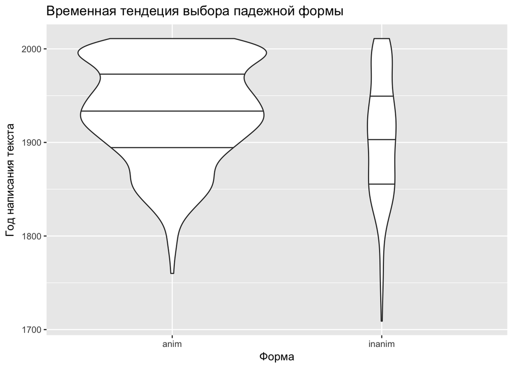

```r
ggplot(nk, aes(form, year)) + geom_violin(scale = "count", draw_quantiles = c(0.25, 0.5, 0.75)) + xlab("Форма") + ylab("Год написания текста") + ggtitle("Временная тендеция выбора падежной формы")
```

### Временная тенденция для разных числительных (на основе данных из НКРЯ)

Рассмотрим также зависимость от времени для различных числительных.

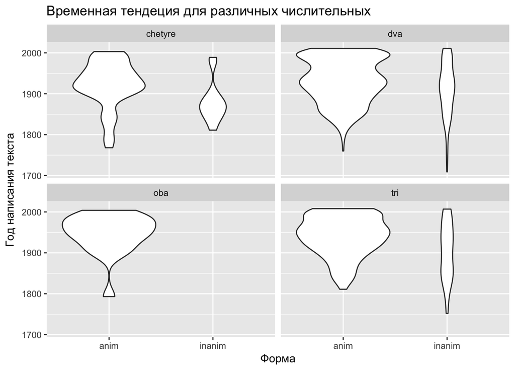

```r
ggplot(nk, aes(form, year)) + geom_violin(scale = "count") + xlab("Форма") + ylab("Год написания текста") + ggtitle("Временная тендеция для различных числительных") + facet_wrap(~numeral)
```

Для числительного оба в НКРЯ вообще не нашлось неодушевленных форм. Для всех остальных числительных видна четкая временная тенденция - чаще начинают употребляться одушевленные формы.

## Заключение

Удалось выяснить, что:

- с течением времени количество употреблений “одушевленных” форм возрастает, а “неодушевленных” – убывает;
- если однородные члены в “неодушевленной” форме, то исследуемая конструкция подвергается их влиянию (чаще используется в “неодушевленной” форме);
- с возрастанием определенности чаще употребляются “одушевленные” формы.